# R Notebook

### Problem:

The primary challenge we aim to address is the effective utilization of predictive analytics to gain insights and make informed decisions based on the supermarket’s historical sales data. Specifically, we seek to predict customer ratings and identify patterns in sales data, enabling the supermarket to enhance customer satisfaction, optimize inventory, and strategically plan marketing campaigns.

### Data Mining Task:

We did the Classification and Clustering for Supermarket Sales our class label is Rating

1-Classification Task: Predicting Customer Satisfaction for the class attribute Ratings:

The goal here is to develop a classification model that predicts whether a customer’s overall shopping experience falls into the categories of “High” or “Low.” Leveraging historical sales data, this predictive model aims to discern patterns and factors influencing customer satisfaction ratings. By employing machine learning algorithms, the classification task seeks to offer insights into the key features that contribute to positive or negative shopping experiences. The outcome of this endeavor will not only enhance our understanding of customer preferences but will also empower the supermarket to proactively address concerns and tailor strategies for an improved overall shopping experience.

2-Clustering Task: Segmentation of Customer Purchase Behavior:

The primary goal here is to implement clustering algorithms for customer segmentation based on key attributes like product line, total spending, and purchase frequency. This segmentation aims to uncover distinct customer groups with similar purchasing behaviors.

### Goal

The growth of supermarkets in most cities is increasing and market competitions are also high , our data set is one of the historical sales of supermarket company which has recorded in 3 different branches for 3 months, it has 13 columns and 1000 rows .Our main goal is clustering and classification our database for the class label rating.

### Data

1- Dataset’s source: https://www.kaggle.com/datasets/aungpyaeap/supermarket-sales

2- Number of object: 1000

3- Number of attributes: 17

4- The Main Characteristics of the attribute is done by several parts will be mention in this report for the graph we did three different graphs such as Histogram of Rating before we did the discretization for rating, Barplot of Rating VS Gender after the discretization, and plot of Unit Price VS Gross Income. moreover we did the boxplot in this r notebook and we indicate the outliers all of this steps done with clear descriptions. The results indicate that our data needs preprocessing steps since the boxplots show us the outliers in the dataset that needs to removed, the plot shows us high values that needs to normalize to standardizes features, preventing biases in favor of variables with larger scales and ensuring fair model evaluation, the Rating type shows us that this attribute needs to be discretized since it is an ordinal we need to convert it into binary type the result will be high and low.

### Data preprocessing

1-Outlier Removal: Why: We removed outliers in multiple numeric columns (‘Total,’ ‘cogs,’ ‘gross.income,’ ‘Quantity,’ and ‘Unit.price’) to enhance dataset quality and reliability, preventing skewed insights or models.

How: We used a custom ‘outlier’ detection function to flag and remove potential outliers in each numeric column.

Justification: Addressing outliers is crucial to maintain accurate statistical measures and improve machine learning model performance, ensuring a more reliable dataset for analysis and predictions.

2-Encoding Categorical Variables: Why: Our dataset contains categorical variables like ‘City,’. To make these variables compatible with machine learning algorithms, we applied encoding to convert them into a numeric format.

How: We used the factor function in R to convert each categorical variable into a factor with specified levels and labels. For example, ‘City’ was encoded into numerical values (1, 2, 3) representing (‘Yangon,’ ‘Mandalay,’ ‘Naypyitaw’). Similarly, ‘Customer.type’ and ‘Gender’ were encoded as binary factors (0, 1), and ‘Product.line’ and ‘Payment’ were encoded into numeric categories (1 to 6 and 1 to 3, respectively).

Justification: Machine learning models require numerical inputs, and encoding categorical variables ensures that our models can effectively interpret and utilize this information. This step is crucial for achieving accurate predictions and insights from our dataset.

3-Normalization of Numeric Features: Why: In our dataset, normalization was applied to numeric features such as ‘Unit.price,’ ‘Quantity,’ ‘Total,’ ‘cogs,’ and ‘gross.income.’ Normalization standardizes the scale of these variables, preventing any single feature from dominating the others during analysis.

How: We utilized the scale function in R to standardize each numeric column independently. This process rescales the values, giving them a mean of 0 and a standard deviation of 1.

Justification: Normalization is crucial for fair feature treatment, better convergence, and enhanced model robustness in machine learning.

4-Rating Discretization: Why: The discretization process was applied to the ‘Rating’ attribute, which originally had ordinal values on a scale from 1 to 10. Converting it into a binary classification of ‘High’ and ‘Low’ simplifies the target variable for our predictive modeling task.

How: We utilized the ifelse function in R, setting a threshold at 6.9 based on the mean. Ratings above this threshold were labeled as ‘High,’ and those below or equal to it were labeled as ‘Low.’

Justification: Discretizing the ‘Rating’ variable into binary categories facilitates classification tasks, making the prediction problem more straightforward. This transformation aligns with our goal of predicting whether a customer’s overall shopping experience is rated as ‘High’ or ‘Low’ based on historical sales data.

### Data Mining Technique:

1- Classification Technique: In the analysis of our dataset, we employed decision tree models, a classification technique, to gain insights into customer ratings. Decision trees are effective for revealing patterns in categorical data and aiding in the prediction of discrete outcomes. We utilized the R programming language along with the ‘rpart’ package for decision tree modeling. Specifically, we applied three different split criteria, namely Information Gain, Gini Index, and Gain Ratio, to evaluate their impact on model performance. The ‘caret’ package facilitated the training and evaluation process, and ‘rpart.plot’ allowed for the visualization of the resulting decision trees. The decision tree models served to uncover the most influential features in predicting customer ratings and provided valuable interpretability in understanding the decision-making process of the models.

2- Cluster Technique: Utilizing the k-means clustering algorithm, this analysis aims to uncover inherent patterns and relationships within an unlabeled dataset. Implemented in R with the cluster package, k-means efficiently groups similar instances iteratively, minimizing the sum of squared distances within each cluster. The factoextra package assists in visualizing clustering results through scatter plots with convex hulls. Key metrics, including the Silhouette Coefficient, Total Within-Cluster Sum of Squares (TWCSS), and BCubed Precision and Recall, provide quantitative assessments of cluster quality. Preprocessing steps involve converting selected columns to numeric types, standardizing data, and removing the “Rating” class label. The iterative application of k-means with varying K values explores diverse cluster configurations, aiding in the identification of the optimal number of clusters. Visualizations and metrics collectively contribute to a comprehensive understanding of underlying data patterns.

### First part of the main Characteristics of the attribute: Attributes :

Invoice id (Nominal): Computer generated sales slip invoice identification number. the possible values are unique id for each object containing 9 digits

Branch (Nominal): Branch of super center (3 branches are available identified by A, B and C).

City (Nominal): Location of supercenters the possibal values are Yangon, Naypyitaw, and Mandalay.

Customer type (Binary): Type of customers, recorded by Members for customers using member card and Normal for without member card.

Gender(Binary): Gender type of customer. the possible values are Female or male

Product line(Nominal): General item categorization groups - Electronic accessories, Fashion accessories, Food and beverages, Health and beauty, Home and lifestyle, Sports and travel.

Unit price(Numeric - ratio): Price of each product in $. the possible values are range from 10.08 to 99.96

Tax(Numeric - ratio): 5% tax fee for customer buying. the possible values are range from 0.5085 to 49.6500

Total(Numeric - Interval): Total price including tax. the possible values are range from 10.68 to 1042.65

Date(Ordinal): Date of purchase (Record available from January 2019 to March 2019)

Time(ordinal): Purchase time .the possible values between (10am to 9pm).

Payment(Nominal): Payment used by customer for purchase (3 methods are available – Cash, Credit card and Ewallet).

COGS(Numeric - Interval): Cost of goods sold. the possible values are range from 10.17 to 993.00

Gross margin percentage(Numeric - ratio): Gross margin percentage it has only one value 4.761905

Gross income(Numeric - ratio): Gross income is the total earnings or income from all sources before taxes.

Rating(ordinal): Customer stratification rating on their overall shopping experience (On a scale of 1 to 10).

Data set link:https://www.kaggle.com/datasets/aungpyaeap/supermarket-sales

we imported the dataset

```r
library(readxl)
dataset <- read.csv("/Users/najlaalajaleen/Desktop/Dataset/supermarketDataset.csv")
View(dataset)
```

#### Second part of the main Characteristics of the attribute: Check nulls value

There is no null values in the dataset

```r
sum(is.na(dataset))
```

```
[1] 0
```

install the libraries

```r
#install.packages("tidyverse")
library(tidyverse)
#install.packages("dplyr")
library(dplyr)
library(stringr)
#install.packages("outliers")
library(outliers)
#install.packages("ggplot2")
library(ggplot2)
```

Delete attribute from dataset because: 1-since every city has one branch then city attribute is a redundant value 2-The Tax and gross income are the same so the tax is a redundant value 3-This attribute contain the same values in all the rows

```r
dataset$Invoice.ID = NULL
dataset$Branch = NULL
dataset$Tax.5. = NULL
dataset$gross.margin.percentage = NULL
```

#### Third part of the main Characteristics of the attribute: Statistical Measures:

The statistical measure will give us an idea about the distribution and central tendency of the numeric variable.

```r
summary(dataset)
```

```
     City           Customer.type         Gender          Product.line         Unit.price       Quantity         Total
 Length:1000        Length:1000        Length:1000        Length:1000        Min.   :10.08   Min.   : 1.00   Min.   :  10.68
 Class :character   Class :character   Class :character   Class :character   1st Qu.:32.88   1st Qu.: 3.00   1st Qu.: 124.42
 Mode  :character   Mode  :character   Mode  :character   Mode  :character   Median :55.23   Median : 5.00   Median : 253.85
                                                                             Mean   :55.67   Mean   : 5.51   Mean   : 322.97
                                                                             3rd Qu.:77.94   3rd Qu.: 8.00   3rd Qu.: 471.35
                                                                             Max.   :99.96   Max.   :10.00   Max.   :1042.65
     Date               Time             Payment               cogs         gross.income         Rating
 Length:1000        Length:1000        Length:1000        Min.   : 10.17   Min.   : 0.5085   Min.   : 4.000
 Class :character   Class :character   Class :character   1st Qu.:118.50   1st Qu.: 5.9249   1st Qu.: 5.500
 Mode  :character   Mode  :character   Mode  :character   Median :241.76   Median :12.0880   Median : 7.000
                                                          Mean   :307.59   Mean   :15.3794   Mean   : 6.973
                                                          3rd Qu.:448.90   3rd Qu.:22.4453   3rd Qu.: 8.500
                                                          Max.   :993.00   Max.   :49.6500   Max.   :10.000
```

1-For “Unit Price,” the distribution ranges from 10.08 to 99.96, with a mean of approximately 55.67. The 1st quartile is around 32.88, and the 3rd quartile is around 77.94.

2-For “Quantity,” the distribution ranges from 1 to 10, with a mean of approximately 5.51. The 1st quartile is around 3, and the 3rd quartile is around 8.

3-For “Total,” the distribution ranges from 10.68 to 1042.65, with a mean of approximately 322.97. The 1st quartile is around 124.42, and the 3rd quartile is around 471.35.

4-For “COGS (Cost of Goods Sold),” the distribution ranges from 10.17 to 993.00, with a mean of approximately 307.59. The 1st quartile is around 118.50, and the 3rd quartile is around 448.90.

5-For “Gross Income,” the distribution ranges from 0.5085 to 49.6500, with a mean of approximately 15.3794. The 1st quartile is around 5.9249, and the 3rd quartile is around 22.4453.

6-For the “Rating,” the distribution ranges from 4 to 10, with a mean of approximately 6.973. The 1st quartile is around 5.5, and the 3rd quartile is around 8.5

### Fourth part of the main Characteristics of the attribute:

Create The Boxplot:

unit price boxplot

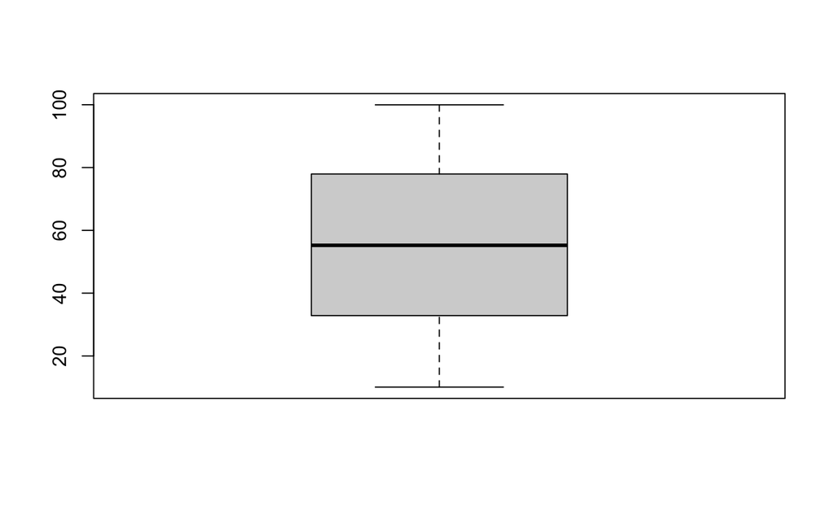

```r
boxplot(dataset$Unit.price)
```

The “Unit Price” boxplot shows that there are no outliers in the “Unit Price” attribute. We noticed that the average was close to 56, with the total unit price ranging from 10 to nearly 100 kyat

Quantity boxplot

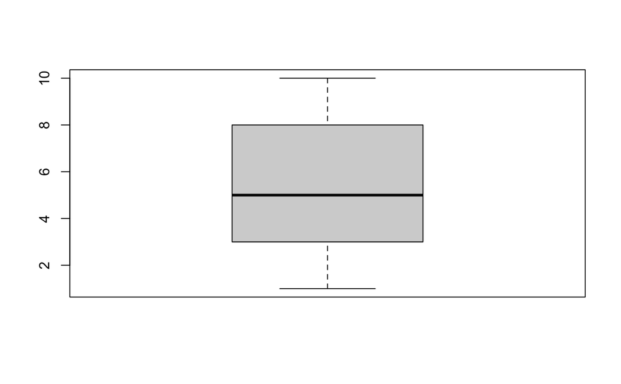

```r
 boxplot(dataset$Quantity)
```

The” Quantity” boxplot shows that there are no outliers in the quantity of this item. We find that the average value of the values is almost 6 and the total number is between 1 and 10

Total boxplot

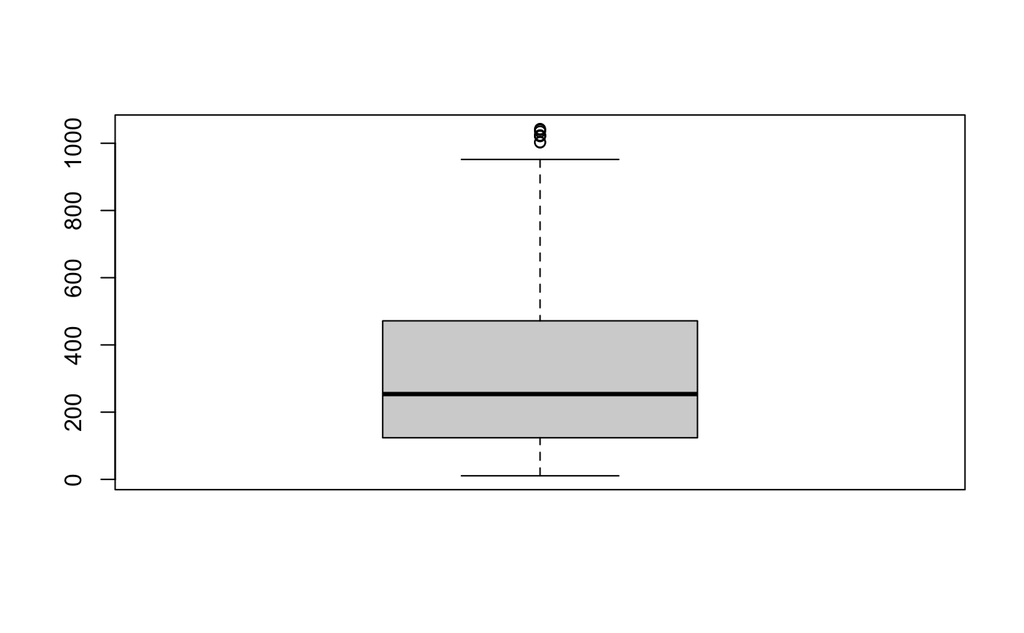

```r
boxplot(dataset$Total)
```

The “Total” boxplot shows that there are outliers that are close to each other and need to be removed during the preprocessing stage. We also notice that the mean of values is close to 320, with outliers existing almost above 900.

cogs boxplot

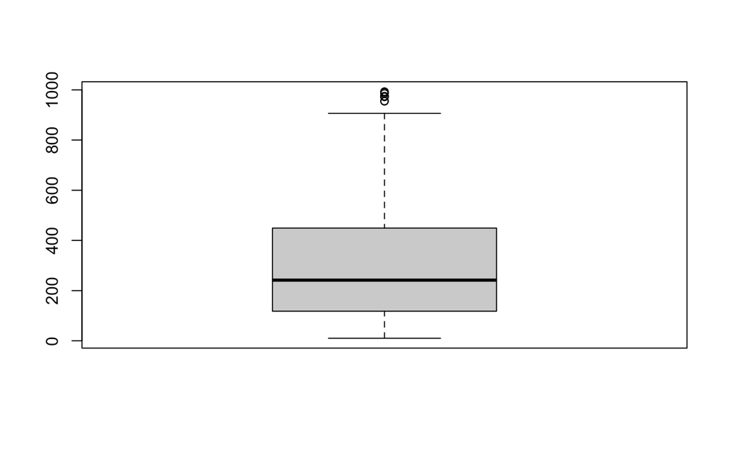

```r
boxplot(dataset$cogs)
```

The “Cogs” illustrates many outliers and the need for preprocessing. We also find that the mean is close to 300 and the outliers are almost over 900.

gross income boxplot

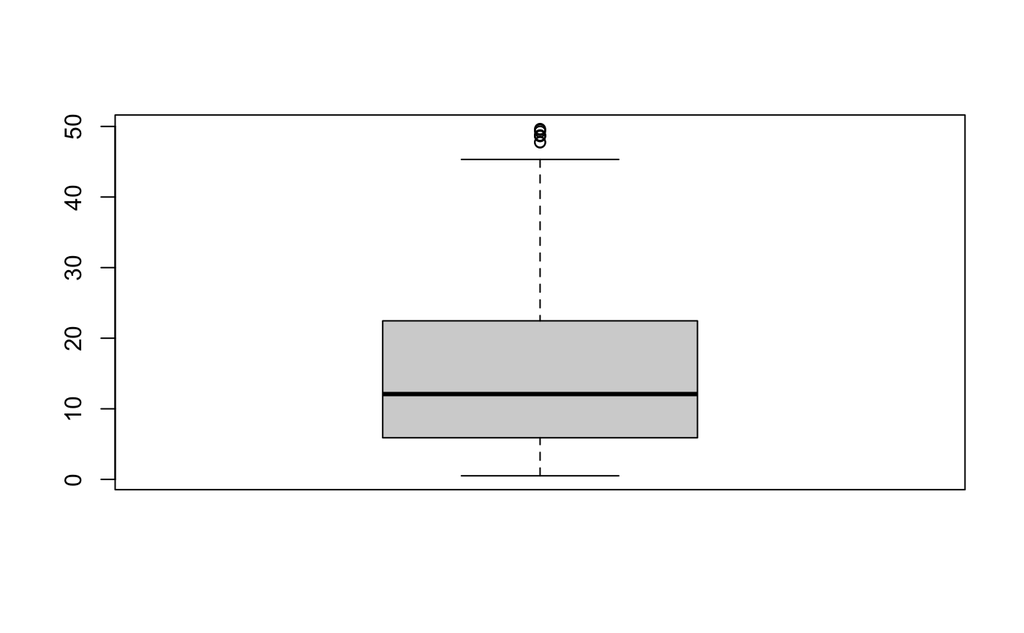

```r
boxplot(dataset$gross.income)
```

The ” Gross income ” boxplot shows many outliers that are very close to each other and needs to be smoothed to remove this noise.

We checked all the numbers to see if there were any outliers. Then, we took out the lines where we found the outliers to make a more accurate dataset that would help us get more accurate results later.

```r
#detict the outliers fot the Total
OutTotal = outlier(dataset$Total, logical =TRUE)
sum(OutTotal)
```

```
[1] 1
```

```r
Find_outlier = which(OutTotal ==TRUE, arr.ind = TRUE)
OutTotal
```

[output not shown]

[output cut: 31 more lines]

```r
Find_outlier
```

```
[1] 351
```

```r
#remove the  fot the Total
dataset= dataset[-Find_outlier,]
```

```r
#detict the outliers for the cogs
OutCogs = outlier(dataset$cogs, logical =TRUE)
sum(OutCogs)
```

```
[1] 1
```

```r
Find_outlier = which(OutCogs ==TRUE, arr.ind = TRUE)
OutCogs
```

[output not shown]

[output cut: 31 more lines]

```r
Find_outlier
```

```
[1] 168
```

```r
#remove the outlier for the cogs
dataset= dataset[-Find_outlier,]
```

```r
#detict the outliers for the gross income
OutGrossIncome = outlier(dataset$gross.income, logical =TRUE)
sum(OutGrossIncome)
```

```
[1] 1
```

```r
Find_outlier = which(OutGrossIncome ==TRUE, arr.ind = TRUE)
OutGrossIncome
```

[output not shown]

[output cut: 31 more lines]

```r
Find_outlier
```

```
[1] 556
```

```r
#remove the outlier for the gross income
dataset= dataset[-Find_outlier,]
```

```r
#detict the outliers the Quantity
OutQuantity = outlier(dataset$Quantity, logical =TRUE)
sum(OutQuantity)
```

```
[1] 116
```

```r
Find_outlier = which(OutQuantity ==TRUE, arr.ind = TRUE)
OutQuantity
```

[output not shown]

[output cut: 31 more lines]

```r
Find_outlier
```

```
  [1]   8  14  15  50  59  64  66  69  71  72  76  79  92  97 106 110 119 139 141 142 143 147 165 167 182 203 207 234 251 263 267 269 276
 [34] 278 279 290 294 314 349 355 356 367 386 390 392 409 421 428 445 456 457 460 464 471 477 480 482 483 485 490 492 527 531 545 559 563
 [67] 564 569 586 600 612 621 625 628 633 647 650 661 668 672 676 685 690 697 700 725 733 735 744 750 756 758 759 790 795 807 809 826 827
[100] 836 851 870 878 880 885 887 904 907 930 940 956 968 986 989 991 994
```

```r
#remove the outlier the Quantity
dataset= dataset[-Find_outlier,]
```

```r
#detict the outliers for the unit price
OutUnitPrice = outlier(dataset$Unit.price, logical =TRUE)
sum(OutUnitPrice)
```

```
[1] 1
```

```r
Find_outlier = which(OutUnitPrice ==TRUE, arr.ind = TRUE)
OutUnitPrice
```

[output not shown]

[output cut: 26 more lines]

```r
Find_outlier
```

```
[1] 832
```

```r
#remove the outlier for the unit price
dataset= dataset[-Find_outlier,]
```

dataset after removing the outliers

```r
summary(dataset)
```

```
     City           Customer.type         Gender          Product.line         Unit.price       Quantity         Total
 Length:880         Length:880         Length:880         Length:880         Min.   :10.13   Min.   :1.000   Min.   : 10.68
 Class :character   Class :character   Class :character   Class :character   1st Qu.:32.85   1st Qu.:3.000   1st Qu.:103.81
 Mode  :character   Mode  :character   Mode  :character   Mode  :character   Median :55.05   Median :5.000   Median :221.95
                                                                             Mean   :55.68   Mean   :4.901   Mean   :287.46
                                                                             3rd Qu.:77.94   3rd Qu.:7.000   3rd Qu.:416.52
                                                                             Max.   :99.96   Max.   :9.000   Max.   :944.62
     Date               Time             Payment               cogs         gross.income         Rating
 Length:880         Length:880         Length:880         Min.   : 10.17   Min.   : 0.5085   Min.   : 4.000
 Class :character   Class :character   Class :character   1st Qu.: 98.87   1st Qu.: 4.9435   1st Qu.: 5.575
 Mode  :character   Mode  :character   Mode  :character   Median :211.38   Median :10.5690   Median : 7.000
                                                          Mean   :273.77   Mean   :13.6885   Mean   : 6.997
                                                          3rd Qu.:396.69   3rd Qu.:19.8345   3rd Qu.: 8.500
                                                          Max.   :899.64   Max.   :44.9820   Max.   :10.000
```

### Fifth part of the main Characteristics of the attribute: Histogram

The histogram represents the frequency of rating weight in the dataset. After observation, we noticed that the most ratings lie in the range, which is approximately from 4 to 10, but also it illustrates there is no outliers. in the dataset.

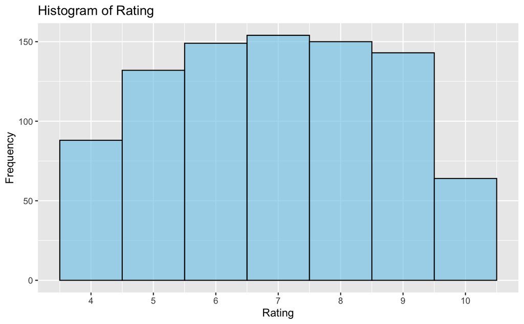

```r
ggplot(dataset, aes(x = Rating)) +
  geom_histogram(binwidth = 1, fill = "skyblue", color = "black", alpha = 0.7) +
  labs(title = "Histogram of Rating", x = "Rating", y = "Frequency") +
  scale_x_continuous(breaks = seq(1, 10, 1))
```

### Sixth part of the main Characteristics of the attribute: Scatter Plot

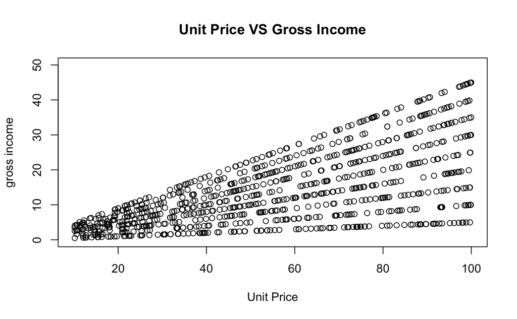

```r
plot(dataset$Unit.price, dataset$gross.income, main = "Unit Price VS Gross Income",
     xlab = "Unit Price", ylab = "gross income",
     xlim = c(10,100), ylim = c(0, 50))
```

convert the date which was character to be date type and extract the month from the dates by discretization

```r
dataset$Date <- format(as.Date(dataset$Date, format = "%d/%m/%Y"), "%m")
```

```r
dataset$Rating <- ifelse(dataset$Rating > 6.9, "High","Low")
table(dataset$Rating)
```

```
High  Low
 446  434
```

```r
prop.table(table(dataset$Rating))
```

```
     High       Low
0.5068182 0.4931818
```

We checked the balanced of the dataset and the result of the dataset demonstrates a balanced distribution between the “High” and “Low” classes, with 446 instances assigned to the “High” class and 434 instances to the “Low” class.

### Seventh part of the main Characteristics of the attribute: Barplot

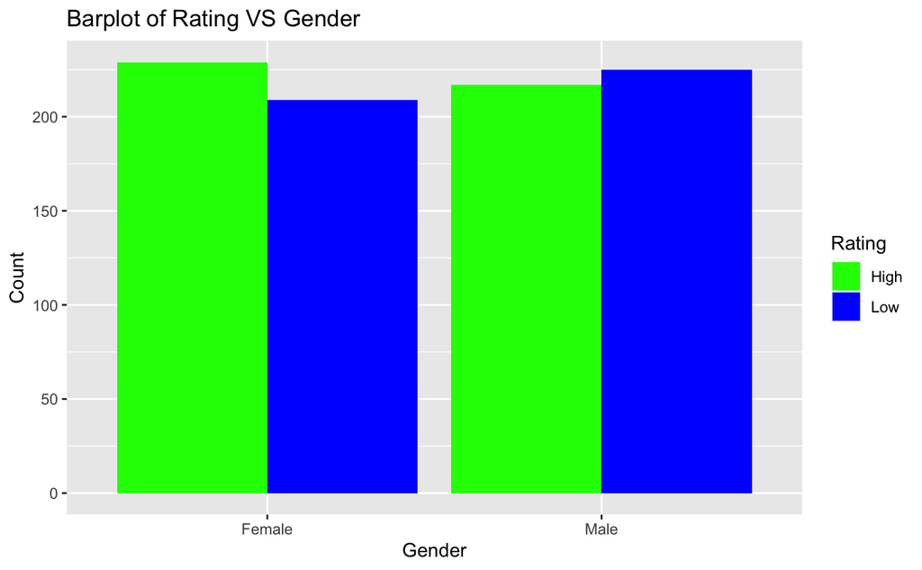

```r
ggplot(dataset, aes(x = Gender, fill = Rating)) +
  geom_bar(position = "dodge", stat = "count") +
  labs(title = "Barplot of Rating VS Gender", x = "Gender", y = "Count") +
  scale_fill_manual(values = c("green", "blue"))
```

The Barplot represents the ratings (low,high) Vs the gender ( female, male) that shows the count of female for the low and high count is approximately more than 200 and for the male count for the high and low approximately also more than 200 counts barplot

Incoding We encode the dataset to enable analysis because most machine learning and statistical analysis methods require numerical data as input and make the data much easier to understand.

```r
dataset$City=factor(dataset$City,
                    levels = c('Yangon','Mandalay','Naypyitaw'),
                    labels = c(1 , 2 , 3))

dataset$Customer.type =factor(dataset$Customer.type,
                              levels = c('Normal','Member'),
                              labels = c(0 , 1))

dataset$Gender =factor(dataset$Gender,
                       levels = c('Female','Male'),
                       labels = c(0 , 1))
dataset$Product.line=factor(dataset$Product.line,
                            levels = c('Health and beauty','Electronic accessories','Home and lifestyle','Sports and travel','Food and beverages','Fashion accessories'),
                            labels = c(1 , 2, 3, 4,5,6))
dataset$Payment=factor(dataset$Payment,
                       levels = c('Ewallet','Cash','Credit card'),
                       labels = c(1 , 2 , 3))
```

normalization We do normalization for datasets to ensure that all features are on the same scale also Normalization makes data more consistent and aids in accurate comparisons and model convergence.

```r
dataset [,5]=scale(dataset [,5])
dataset [,6]=scale(dataset [,6])
dataset [,7]=scale(dataset [,7])
dataset [,11:12]=scale(dataset[,11:12])
```

we used substr to cut the time and depend only on the hours

```r
dataset$Time <- substr(dataset$Time, 1, 2)
```

##### We didn’t apply feature selection for our dataset because we need our attribute for the next phase

### Classification

Load the necessary libraries

```r
library(rpart)
library(caret)
library(rpart.plot)
```

```r
features <- dataset[, c("City", "Customer.type", "Gender", "Product.line", "Unit.price", "Quantity", "Total", "Payment")]
target <- (dataset$Rating)
set.seed(1234)
splits <- createDataPartition(target, p = 0.85, list = FALSE)
train_data <- dataset[splits, ]
test_data <- dataset[-splits, ]
```

Tree for Information gain 85%

```r
model <- train(
  x = train_data[, c("City", "Customer.type", "Gender", "Product.line", "Unit.price", "Quantity", "Total", "Payment", "Date", "Time","gross.income", "cogs")],
  y = train_data$Rating,
  method = "rpart",
  parms = list(split = "information"),
  trControl = trainControl(method = "cv", number=3)
)
predictions <- predict(model, newdata = test_data)

# Evaluate the model
predictions<- factor(predictions)
test_data$Rating <- factor(test_data$Rating)
confusion_matrix <- confusionMatrix(predictions, test_data$Rating)
print(confusion_matrix)
```

```
Confusion Matrix and Statistics

          Reference
Prediction High Low
      High   37  34
      Low    29  31

               Accuracy : 0.5191
                 95% CI : (0.4301, 0.6072)
    No Information Rate : 0.5038
    P-Value [Acc > NIR] : 0.3968

                  Kappa : 0.0376

 Mcnemar's Test P-Value : 0.6143

            Sensitivity : 0.5606
            Specificity : 0.4769
         Pos Pred Value : 0.5211
         Neg Pred Value : 0.5167
             Prevalence : 0.5038
         Detection Rate : 0.2824
   Detection Prevalence : 0.5420
      Balanced Accuracy : 0.5188

       'Positive' Class : High
```

```r
true_positives <- confusion_matrix$table[1, 1]
false_positives <- confusion_matrix$table[1, 2]

precision <- true_positives / (true_positives + false_positives)

# Print the Precision
cat("Precision:", precision, "\n")
```

```
Precision: 0.5211268
```

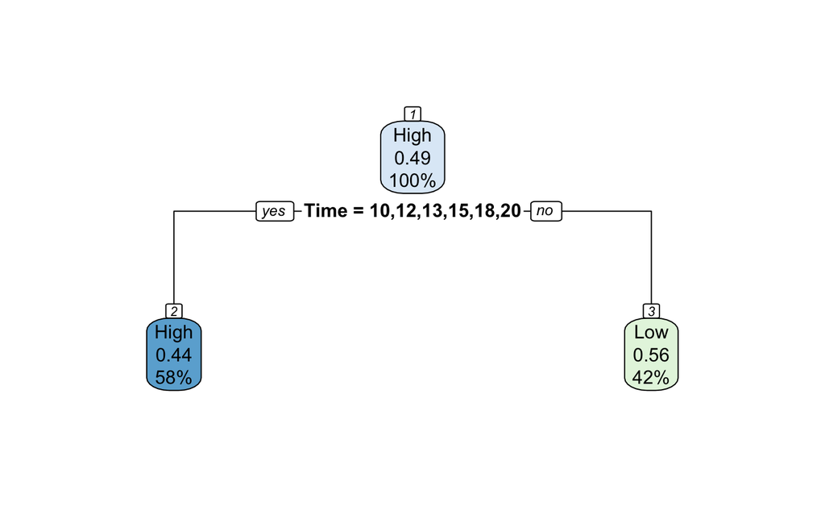

```r
rpart_model <- model$finalModel
rpart.plot(rpart_model, box.palette = "auto", nn = TRUE)
```

The information gain tree showed us the most important attribute for predicting customer rating which is “Time”

Sensitivity: 56.06% Specificity: 47.69% Precision: 52.11% Accuracy: 51.91%

The results indicate that:

Precision: The model correctly identifies the positive class (High) about 52.11% of the time. Accuracy: Overall, the model correctly predicts the class about 51.91% of the time. Sensitivity: The model is able to correctly identify the true positives (High) 56.06% of the time. Specificity: The model is able to correctly identify the true negatives (Low) 47.69% of the time.

Gini index 85%

```r
model <- train(
  x = train_data[, c("City", "Customer.type", "Gender", "Product.line", "Unit.price", "Quantity", "Total", "Payment")],
  y = train_data$Rating,
  method = "rpart",
  parms = list(split = "gini"),
  trControl = trainControl(method = "cv", number = 3)
)

predictions<- factor(predictions)
test_data$Rating <- factor(test_data$Rating)
confusion_matrix <- confusionMatrix(predictions, test_data$Rating)
print(confusion_matrix)
```

```
Confusion Matrix and Statistics

          Reference
Prediction High Low
      High   37  34
      Low    29  31

               Accuracy : 0.5191
                 95% CI : (0.4301, 0.6072)
    No Information Rate : 0.5038
    P-Value [Acc > NIR] : 0.3968

                  Kappa : 0.0376

 Mcnemar's Test P-Value : 0.6143

            Sensitivity : 0.5606
            Specificity : 0.4769
         Pos Pred Value : 0.5211
         Neg Pred Value : 0.5167
             Prevalence : 0.5038
         Detection Rate : 0.2824
   Detection Prevalence : 0.5420
      Balanced Accuracy : 0.5188

       'Positive' Class : High
```

```r
true_positives <- confusion_matrix$table[1, 1]
false_positives <- confusion_matrix$table[1, 2]

precision <- true_positives / (true_positives + false_positives)

# Print the Precision
cat("Precision:", precision, "\n")
```

```
Precision: 0.5211268
```

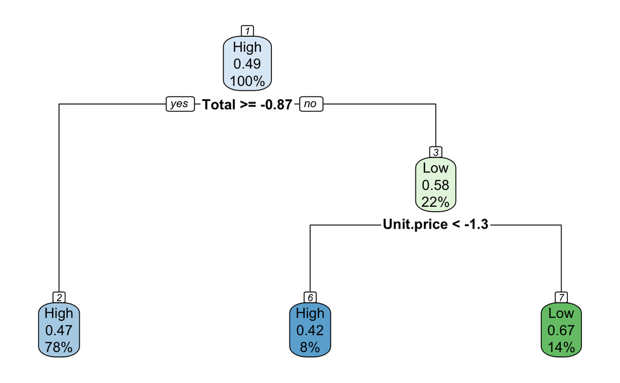

```r
rpart_model <- model$finalModel
rpart.plot(rpart_model, box.palette = "auto", nn = TRUE)
```

The gini tree is a simple tree with two splits, the first split is based on total if the total higher than or equal to -0.87 then it will predict high, otherwise will do the next split which is based on Unit Price if it is less than -1.3 then will predict high otherwise will predict low.

Gain ratio

```r
model <- train(
  x = train_data[, c("City", "Customer.type", "Gender", "Product.line", "Unit.price", "Quantity", "Total", "Payment", "Date", "Time","gross.income", "cogs")],
  y = train_data$Rating,
  method = "rpart",
  parms = list(split = "gain_ratio"),
  trControl = trainControl(method = "cv", number = 3)
)
predictions <- predict(model, newdata = test_data)

# Evaluate the model
predictions<- factor(predictions)
test_data$Rating <- factor(test_data$Rating)
confusion_matrix <- confusionMatrix(predictions, test_data$Rating)
print(confusion_matrix)
```

```
Confusion Matrix and Statistics

          Reference
Prediction High Low
      High   26  25
      Low    40  40

               Accuracy : 0.5038
                 95% CI : (0.4152, 0.5923)
    No Information Rate : 0.5038
    P-Value [Acc > NIR] : 0.53488

                  Kappa : 0.0093

 Mcnemar's Test P-Value : 0.08248

            Sensitivity : 0.3939
            Specificity : 0.6154
         Pos Pred Value : 0.5098
         Neg Pred Value : 0.5000
             Prevalence : 0.5038
         Detection Rate : 0.1985
   Detection Prevalence : 0.3893
      Balanced Accuracy : 0.5047

       'Positive' Class : High
```

```r
true_positives <- confusion_matrix$table[1, 1]
false_positives <- confusion_matrix$table[1, 2]

precision <- true_positives / (true_positives + false_positives)

# Print the Precision
cat("Precision:", precision, "\n")
```

```
Precision: 0.5098039
```

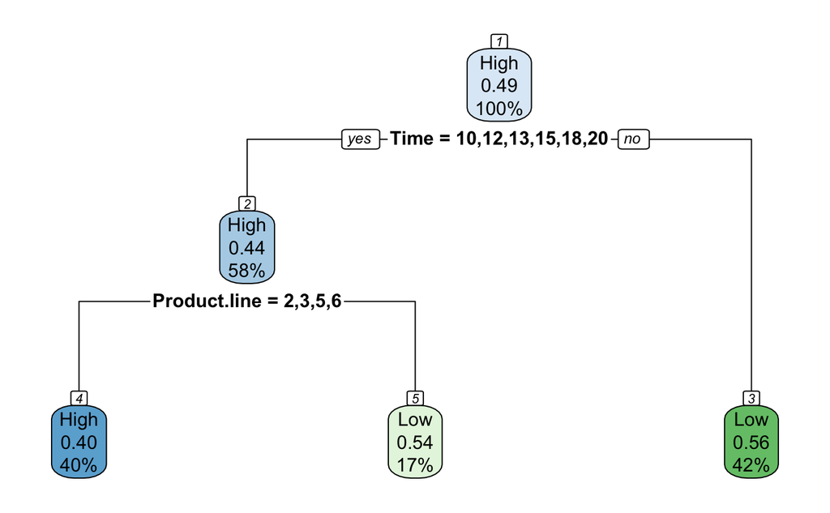

```r
rpart_model <- model$finalModel
rpart.plot(rpart_model, box.palette = "auto", nn = TRUE)
```

The gain ratio tree is a simple tree with two splits, the first split is based on time if the time does not equal 10, 12, 13, 15, 18, 20 then it will predict low, otherwise will do the next split which is based on product line if it is equal to 2(Electronic accessories),3(Home and lifestyle),5(Food and beverages),6(Fashion accessories) than it will predict high otherwise will predict low.

Precision: 50,98% Accuracy: 50.38% Sensitivity: 39.39% Specificity: 61.54%

The results indicate that:

Precision: The model correctly identifies the positive class (High) about 50,98% of the time. Accuracy: Overall, the model correctly predicts the class about 50.38% of the time. Sensitivity: The model is able to correctly identify the true positives (High) 39.39% of the time. Specificity: The model is able to correctly identify the true negatives (Low) 61.54% of the time.

Start the partition 80% for training:

```r
features <- dataset[, c("City", "Customer.type", "Gender", "Product.line", "Unit.price", "Quantity", "Total", "Payment")]
target <- (dataset$Rating)
set.seed(1234)
splits <- createDataPartition(target, p = 0.80, list = FALSE)
train_data <- dataset[splits, ]
test_data <- dataset[-splits, ]
```

Tree for Information gain 80%

```r
model <- train(
  x = train_data[, c("City", "Customer.type", "Gender", "Product.line", "Unit.price", "Quantity", "Total", "Payment", "Date", "Time","gross.income", "cogs")],
  y = train_data$Rating,
  method = "rpart",
  parms = list(split = "information"),
  trControl = trainControl(method = "cv", number=3)
)
predictions <- predict(model, newdata = test_data)

# Evaluate the model
predictions<- factor(predictions)
test_data$Rating <- factor(test_data$Rating)
confusion_matrix <- confusionMatrix(predictions, test_data$Rating)
print(confusion_matrix)
```

```
Confusion Matrix and Statistics

          Reference
Prediction High Low
      High   36  28
      Low    53  58

               Accuracy : 0.5371
                 95% CI : (0.4603, 0.6127)
    No Information Rate : 0.5086
    P-Value [Acc > NIR] : 0.248244

                  Kappa : 0.0785

 Mcnemar's Test P-Value : 0.007661

            Sensitivity : 0.4045
            Specificity : 0.6744
         Pos Pred Value : 0.5625
         Neg Pred Value : 0.5225
             Prevalence : 0.5086
         Detection Rate : 0.2057
   Detection Prevalence : 0.3657
      Balanced Accuracy : 0.5395

       'Positive' Class : High
```

```r
true_positives <- confusion_matrix$table[1, 1]
false_positives <- confusion_matrix$table[1, 2]

precision <- true_positives / (true_positives + false_positives)

# Print the Precision
cat("Precision:", precision, "\n")
```

```
Precision: 0.5625
```

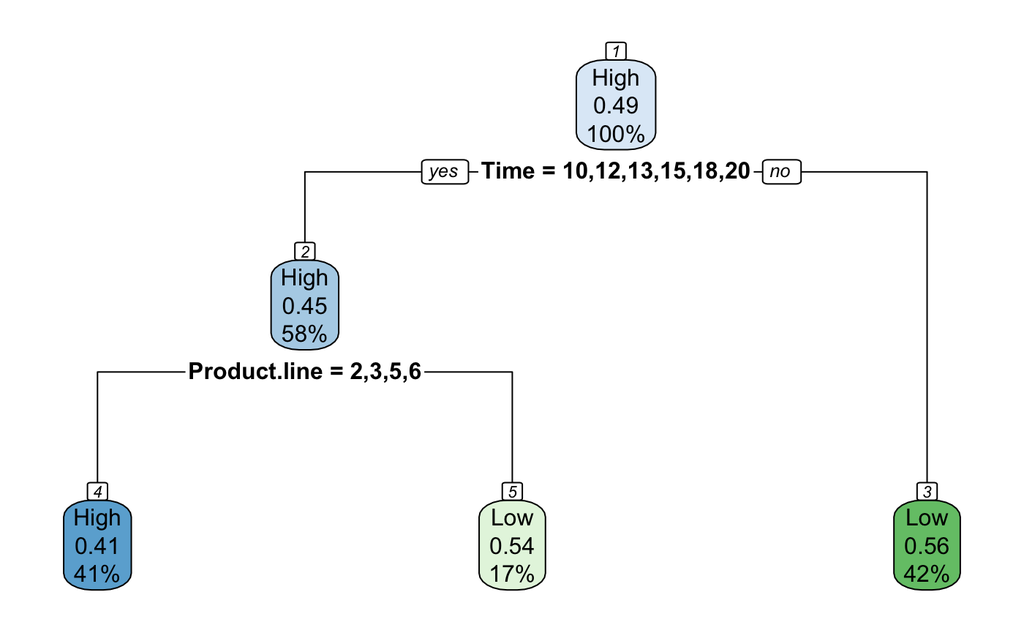

```r
rpart_model <- model$finalModel
rpart.plot(rpart_model, box.palette = "auto", nn = TRUE)
```

The information gain splits the tree based on the Time attribute if the time does not equal to 10,12,13,15,18,20 then it will predict low else will split based on the product line if the product line equal to 2(Electronic accessories),3(Home and lifestyle),5(Food and beverages),6(Fashion accessories) then it will predict high else will predict low.

Precision: 56.25% Accuracy: 53.71% Sensitivity: 40.45% Specificity: 67.44%

The results indicate that:

Precision: The model correctly identifies the positive class (High) about 56.25% of the time. Accuracy: Overall, the model correctly predicts the class about 53.71% of the time. Sensitivity: The model is able to correctly identify the true positives (High) 40.45% of the time. Specificity: The model is able to correctly identify the true negatives (Low) 67.44% of the time.

Gini index 80%

```r
model <- train(
  x = train_data[, c("City", "Customer.type", "Gender", "Product.line", "Unit.price", "Quantity", "Total", "Payment")],
  y = train_data$Rating,
  method = "rpart",
  parms = list(split = "gini"),
  trControl = trainControl(method = "cv", number = 3)
)

predictions<- factor(predictions)
test_data$Rating <- factor(test_data$Rating)
confusion_matrix <- confusionMatrix(predictions, test_data$Rating)
print(confusion_matrix)
```

```
Confusion Matrix and Statistics

          Reference
Prediction High Low
      High   36  28
      Low    53  58

               Accuracy : 0.5371
                 95% CI : (0.4603, 0.6127)
    No Information Rate : 0.5086
    P-Value [Acc > NIR] : 0.248244

                  Kappa : 0.0785

 Mcnemar's Test P-Value : 0.007661

            Sensitivity : 0.4045
            Specificity : 0.6744
         Pos Pred Value : 0.5625
         Neg Pred Value : 0.5225
             Prevalence : 0.5086
         Detection Rate : 0.2057
   Detection Prevalence : 0.3657
      Balanced Accuracy : 0.5395

       'Positive' Class : High
```

```r
true_positives <- confusion_matrix$table[1, 1]
false_positives <- confusion_matrix$table[1, 2]

precision <- true_positives / (true_positives + false_positives)

# Print the Precision
cat("Precision:", precision, "\n")
```

```
Precision: 0.5625
```

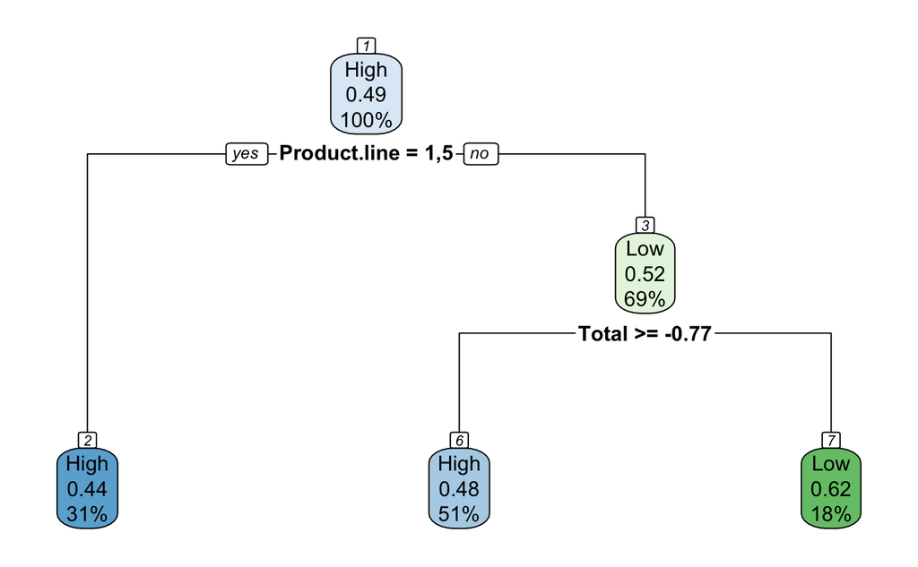

```r
rpart_model <- model$finalModel
rpart.plot(rpart_model, box.palette = "auto", nn = TRUE)
```

This gini index is split the tree based on the product line if the product line equal to 1(Health and beauty), 5(Food and beverages) will predict high else will split the tree based on the total if the total larger or equal to -0.77 will predict high else will predict low

Precision: 56.25% Accuracy: 53.71% Sensitivity: 40.45% Specificity: 67.44%

The results indicate that:

Precision: The model correctly identifies the positive class (High) about 56.25% of the time. Accuracy: Overall, the model correctly predicts the class about 53.71% of the time. Sensitivity: The model is able to correctly identify the true positives (High) 40.45% of the time. Specificity: The model is able to correctly identify the true negatives (Low) 67.44% of the time.

Gain ratio 80%

```r
model <- train(
  x = train_data[, c("City", "Customer.type", "Gender", "Product.line", "Unit.price", "Quantity", "Total", "Payment", "Date", "Time","gross.income", "cogs")],
  y = train_data$Rating,
  method = "rpart",
  parms = list(split = "gain_ratio"),
  trControl = trainControl(method = "cv", number = 3)
)
predictions <- predict(model, newdata = test_data)

# Evaluate the model
predictions<- factor(predictions)
train_data$Rating <- factor(train_data$Rating, levels = levels(test_data$Rating))
test_data$Rating <- factor(test_data$Rating)
confusion_matrix <- confusionMatrix(predictions, test_data$Rating)
print(confusion_matrix)
```

```
Confusion Matrix and Statistics

          Reference
Prediction High Low
      High   51  42
      Low    38  44

               Accuracy : 0.5429
                 95% CI : (0.466, 0.6182)
    No Information Rate : 0.5086
    P-Value [Acc > NIR] : 0.2029

                  Kappa : 0.0847

 Mcnemar's Test P-Value : 0.7373

            Sensitivity : 0.5730
            Specificity : 0.5116
         Pos Pred Value : 0.5484
         Neg Pred Value : 0.5366
             Prevalence : 0.5086
         Detection Rate : 0.2914
   Detection Prevalence : 0.5314
      Balanced Accuracy : 0.5423

       'Positive' Class : High
```

```r
true_positives <- confusion_matrix$table[1, 1]
false_positives <- confusion_matrix$table[1, 2]

precision <- true_positives / (true_positives + false_positives)

# Print the Precision
cat("Precision:", precision, "\n")
```

```
Precision: 0.5483871
```

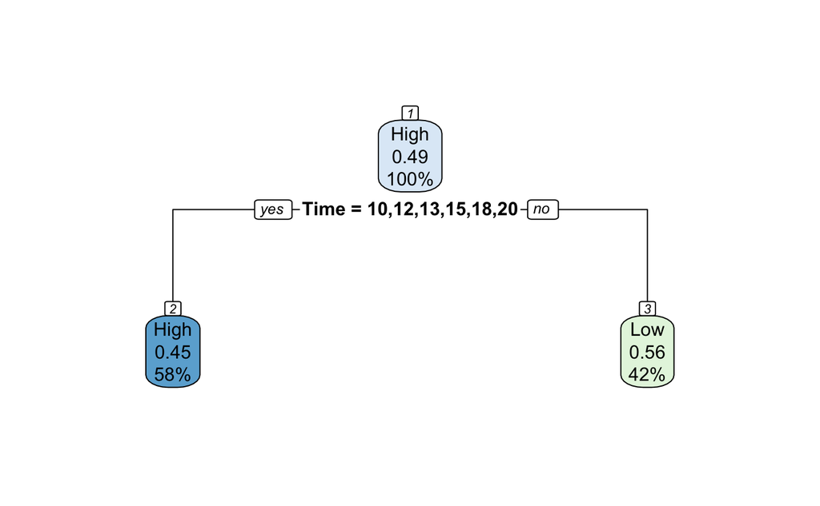

```r
rpart_model <- model$finalModel
rpart.plot(rpart_model, box.palette = "auto", nn = TRUE)
```

This Gain ratio is split the tree based on the time

Precision: 54.83% Accuracy: 54.29% Sensitivity: 57.30% Specificity: 51.16%

The results indicate that:

Precision: The model correctly identifies the positive class (High) about 54.83% of the time. Accuracy: Overall, the model correctly predicts the class about 54.29% of the time. Sensitivity: The model is able to correctly identify the true positives (High) 57.30% of the time. Specificity: The model is able to correctly identify the true negatives (Low) 51.16% of the time.

Start the partition 60% for training:

```r
features <- dataset[, c("City", "Customer.type", "Gender", "Product.line", "Unit.price", "Quantity", "Total", "Payment")]
target <- (dataset$Rating)
set.seed(1234)
splits <- createDataPartition(target, p = 0.60, list = FALSE)
train_data <- dataset[splits, ]
test_data <- dataset[-splits, ]
```

Tree for Information gain 60%

```r
model <- train(
  x = train_data[, c("City", "Customer.type", "Gender", "Product.line", "Unit.price", "Quantity", "Total", "Payment", "Date", "Time","gross.income", "cogs")],
  y = train_data$Rating,
  method = "rpart",
  parms = list(split = "information"),
  trControl = trainControl(method = "cv", number=3)
)
predictions <- predict(model, newdata = test_data)

# Evaluate the model
predictions<- factor(predictions)
test_data$Rating <- factor(test_data$Rating)
confusion_matrix <- confusionMatrix(predictions, test_data$Rating)
print(confusion_matrix)
```

```
Confusion Matrix and Statistics

          Reference
Prediction High Low
      High   54  56
      Low   124 117

               Accuracy : 0.4872
                 95% CI : (0.4338, 0.5408)
    No Information Rate : 0.5071
    P-Value [Acc > NIR] : 0.7884

                  Kappa : -0.0202

 Mcnemar's Test P-Value : 5.918e-07

            Sensitivity : 0.3034
            Specificity : 0.6763
         Pos Pred Value : 0.4909
         Neg Pred Value : 0.4855
             Prevalence : 0.5071
         Detection Rate : 0.1538
   Detection Prevalence : 0.3134
      Balanced Accuracy : 0.4898

       'Positive' Class : High
```

```r
true_positives <- confusion_matrix$table[1, 1]
false_positives <- confusion_matrix$table[1, 2]

precision <- true_positives / (true_positives + false_positives)

# Print the Precision
cat("Precision:", precision, "\n")
```

```
Precision: 0.4909091
```

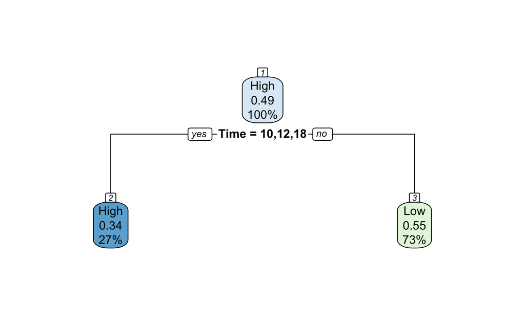

```r
rpart_model <- model$finalModel
rpart.plot(rpart_model, box.palette = "auto", nn = TRUE)
```

Precision: The model correctly identifies the positive class (High) about 49.09% of the time. Accuracy: Overall, the model correctly predicts the class about 48.72% of the time. Sensitivity: The model is able to correctly identify the true positives (High) 30.34% of the time. Specificity: The model is able to correctly identify the true negatives (Low) 67.63% of the time.

Gini index 60%

```r
model <- train(
  x = train_data[, c("City", "Customer.type", "Gender", "Product.line", "Unit.price", "Quantity", "Total", "Payment")],
  y = train_data$Rating,
  method = "rpart",
  parms = list(split = "gini"),
  trControl = trainControl(method = "cv", number = 3)
)

predictions<- factor(predictions)
test_data$Rating <- factor(test_data$Rating)
confusion_matrix <- confusionMatrix(predictions, test_data$Rating)
print(confusion_matrix)
```

```
Confusion Matrix and Statistics

          Reference
Prediction High Low
      High   54  56
      Low   124 117

               Accuracy : 0.4872
                 95% CI : (0.4338, 0.5408)
    No Information Rate : 0.5071
    P-Value [Acc > NIR] : 0.7884

                  Kappa : -0.0202

 Mcnemar's Test P-Value : 5.918e-07

            Sensitivity : 0.3034
            Specificity : 0.6763
         Pos Pred Value : 0.4909
         Neg Pred Value : 0.4855
             Prevalence : 0.5071
         Detection Rate : 0.1538
   Detection Prevalence : 0.3134
      Balanced Accuracy : 0.4898

       'Positive' Class : High
```

```r
true_positives <- confusion_matrix$table[1, 1]
false_positives <- confusion_matrix$table[1, 2]

precision <- true_positives / (true_positives + false_positives)

# Print the Precision
cat("Precision:", precision, "\n")
```

```
Precision: 0.4909091
```

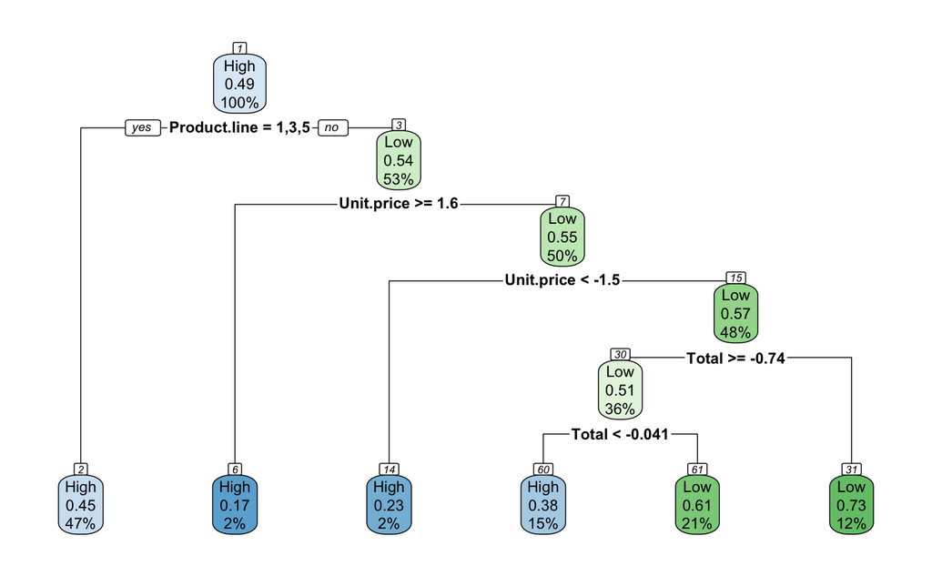

```r
rpart_model <- model$finalModel
rpart.plot(rpart_model, box.palette = "auto", nn = TRUE)
```

Precision: The model correctly identifies the positive class (High) about 49.09% of the time. Accuracy: Overall, the model correctly predicts the class about 48.72% of the time. Sensitivity: The model is able to correctly identify the true positives (High) 30.34% of the time. Specificity: The model is able to correctly identify the true negatives (Low) 67.63% of the time.

Gain ratio 60%

```r
model <- train(
  x = train_data[, c("City", "Customer.type", "Gender", "Product.line", "Unit.price", "Quantity", "Total", "Payment", "Date", "Time","gross.income", "cogs")],
  y = train_data$Rating,
  method = "rpart",
  parms = list(split = "gain_ratio"),
  trControl = trainControl(method = "cv", number = 3)
)
predictions <- predict(model, newdata = test_data)

# Evaluate the model
predictions<- factor(predictions)
test_data$Rating <- factor(test_data$Rating)
confusion_matrix <- confusionMatrix(predictions, test_data$Rating)
print(confusion_matrix)
```

```
Confusion Matrix and Statistics

          Reference
Prediction High Low
      High   56  63
      Low   122 110

               Accuracy : 0.4729
                 95% CI : (0.4197, 0.5266)
    No Information Rate : 0.5071
    P-Value [Acc > NIR] : 0.909

                  Kappa : -0.0493

 Mcnemar's Test P-Value : 2.006e-05

            Sensitivity : 0.3146
            Specificity : 0.6358
         Pos Pred Value : 0.4706
         Neg Pred Value : 0.4741
             Prevalence : 0.5071
         Detection Rate : 0.1595
   Detection Prevalence : 0.3390
      Balanced Accuracy : 0.4752

       'Positive' Class : High
```

```r
true_positives <- confusion_matrix$table[1, 1]
false_positives <- confusion_matrix$table[1, 2]

precision <- true_positives / (true_positives + false_positives)

# Print the Precision
cat("Precision:", precision, "\n")
```

```
Precision: 0.4705882
```

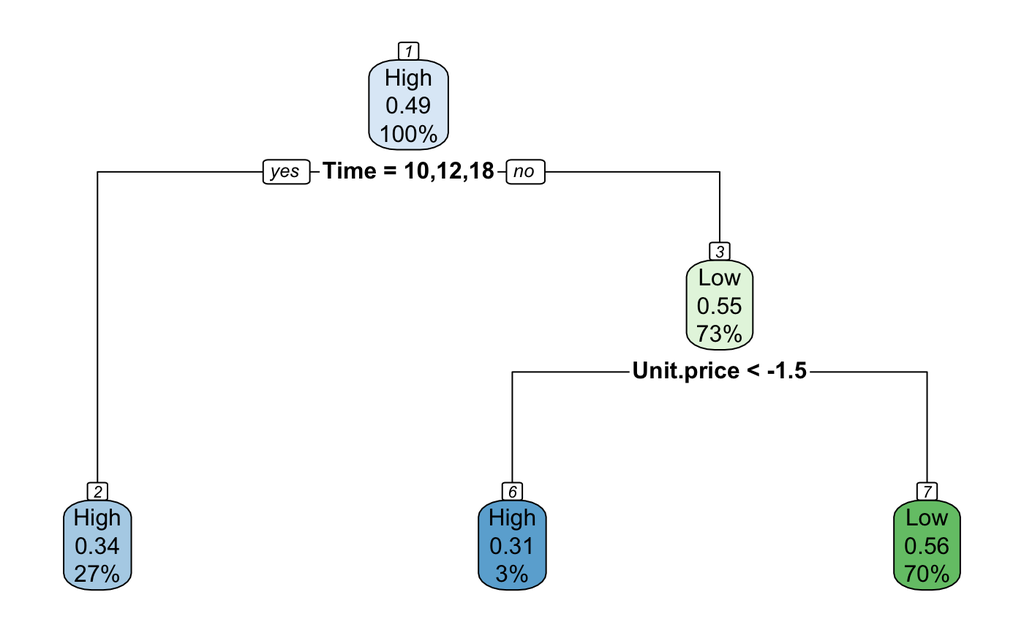

```r
rpart_model <- model$finalModel
rpart.plot(rpart_model, box.palette = "auto", nn = TRUE)
```

Precision: The model correctly identifies the positive class (High) about 47.06% of the time. Accuracy: Overall, the model correctly predicts the class about 47.29% of the time. Sensitivity: The model is able to correctly identify the true positives (High) 31.46% of the time. Specificity: The model is able to correctly identify the true negatives (Low) 63.58% of the time.

|  | 85% | 85% | 85% | 80% | 80% | 80% | 60% | 60% | 60% |
| --- | --- | --- | --- | --- | --- | --- | --- | --- | --- |
| Partitioning | IG | Gini Index | IG ratio | IG | Gini Index | IG ratio | IG | Gini Index | IG ratio |
| Accuracy | 51.91% | 51.91% | 50.38% | 53.71% | 53.71% | 54.29% | 48.72% | 48.72% | 47.29% |
| Precision | 52.11% | 52.11% | 50.98% | 56.25% | 56.25% | 54.84% | 49.09% | 49.09% | 47.06% |
| Sensitivity | 56.06% | 56.06% | 39.39% | 40.45% | 40.45% | 57.30% | 30.34% | 30.34% | 31.46% |
| Specificity | 47.69% | 47.69% | 61.54% | 67.44% | 67.44% | 51.16% | 67.63% | 67.63% | 63.58% |

#### Clustering

Load required libraries

```r
library(tidyverse)
library(cluster)
library(factoextra)
library(NbClust)
library(fpc)
```

Convert data types to numeric

```r
dataset$City <- as.numeric(dataset$City)
dataset$Customer.type <- as.numeric(dataset$Customer.type)
dataset$Gender <- as.numeric(dataset$Gender)
dataset$Product.line <- as.numeric(dataset$Product.line)
dataset$Date <- as.numeric(dataset$Date)
dataset$Time <- as.numeric(dataset$Time)
dataset$Payment <- as.numeric(dataset$Payment)
```

Remove the class lable “Rating”

```r
dataset <- subset(dataset, select = -c(Rating))
```

```r
selected_cols <- c("Unit.price", "Quantity", "Total", "cogs", "gross.income", "City", "Customer.type",
                   "Gender" , "Product.line", "Date", "Time", "Payment")
standardized_data <- scale(dataset[selected_cols])
```

The clustering result for K=3

```r
k = 3

kmeans_result <- kmeans(standardized_data, centers = k, nstart = 25)


silhouette_score <- silhouette(kmeans_result$cluster, dist(standardized_data))


twcss <- sum(kmeans_result$withinss)

cluster_stats <- cluster.stats(dist(standardized_data), kmeans_result$cluster)
bcubed_precision <- cluster_stats$average.within / cluster_stats$average.distance
bcubed_recall <- cluster_stats$average.between / cluster_stats$average.toother

cat("Number of clusters (K):", k, "\n")
```

```
Number of clusters (K): 3
```

```r
cat("Silhouette coefficient:", mean(silhouette_score[, 3]), "\n")
```

```
Silhouette coefficient: 0.1354893
```

```r
cat("Total within-cluster sum of square:", twcss, "\n")
```

```
Total within-cluster sum of square: 7452.957
```

```r
cat("BCubed Precision:", bcubed_precision, "\n")
```

```
BCubed Precision: 1.017659 0.969685 1.007736
```

```r
cat("BCubed Recall:", bcubed_recall, "\n")
```

```
BCubed Recall: 1.03084 0.9292188 1.040054
```

The plot of K = 3

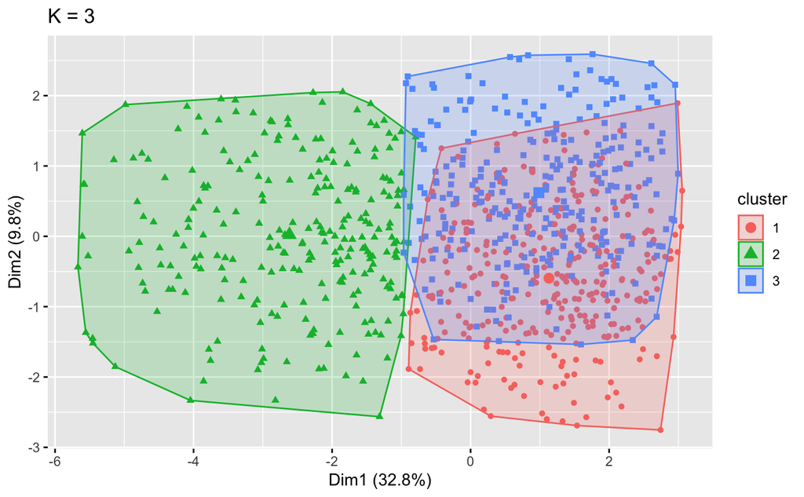

```r
fviz_cluster(kmeans_result, data = standardized_data, geom = "point",
             ellipse.type = "convex", main = paste("K =", k))
```

The clustering result for K=4

```r
k = 4

kmeans_result <- kmeans(standardized_data, centers = k, nstart = 25)


silhouette_score <- silhouette(kmeans_result$cluster, dist(standardized_data))


twcss <- sum(kmeans_result$withinss)

cluster_stats <- cluster.stats(dist(standardized_data), kmeans_result$cluster)
bcubed_precision <- cluster_stats$average.within / cluster_stats$average.distance
bcubed_recall <- cluster_stats$average.between / cluster_stats$average.toother

cat("Number of clusters (K):", k, "\n")
```

```
Number of clusters (K): 4
```

```r
cat("Silhouette coefficient:", mean(silhouette_score[, 3]), "\n")
```

```
Silhouette coefficient: 0.1048482
```

```r
cat("Total within-cluster sum of square:", twcss, "\n")
```

```
Total within-cluster sum of square: 7053.492
```

```r
cat("BCubed Precision:", bcubed_precision, "\n")
```

```
BCubed Precision: 0.987232 1.004458 1.008847 1.003207
```

```r
cat("BCubed Recall:", bcubed_recall, "\n")
```

```
BCubed Recall: 1.061042 1.024579 0.8550705 1.017749
```

The plot of K = 4

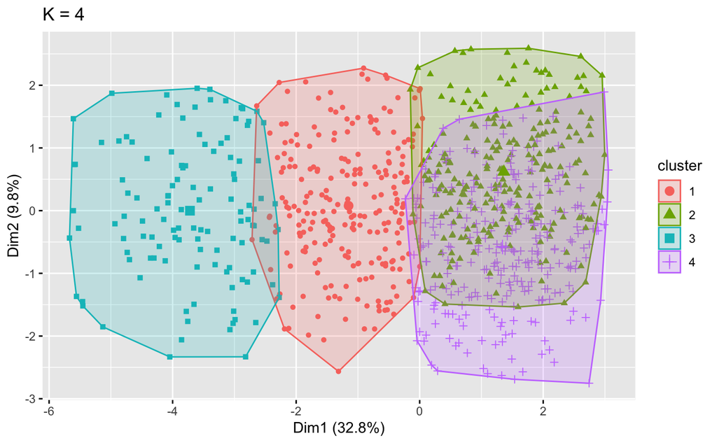

```r
fviz_cluster(kmeans_result, data = standardized_data, geom = "point",
             ellipse.type = "convex", main = paste("K =", k))
```

The clustering result for K = 5

```r
k = 5

kmeans_result <- kmeans(standardized_data, centers = k, nstart = 25)


silhouette_score <- silhouette(kmeans_result$cluster, dist(standardized_data))


twcss <- sum(kmeans_result$withinss)

cluster_stats <- cluster.stats(dist(standardized_data), kmeans_result$cluster)
bcubed_precision <- cluster_stats$average.within / cluster_stats$average.distance
bcubed_recall <- cluster_stats$average.between / cluster_stats$average.toother

cat("Number of clusters (K):", k, "\n")
```

```
Number of clusters (K): 5
```

```r
cat("Silhouette coefficient:", mean(silhouette_score[, 3]), "\n")
```

```
Silhouette coefficient: 0.09929829
```

```r
cat("Total within-cluster sum of square:", twcss, "\n")
```

```
Total within-cluster sum of square: 6736.483
```

```r
cat("BCubed Precision:", bcubed_precision, "\n")
```

```
BCubed Precision: 0.976906 1.012718 1.022773 0.9990613 0.9851579
```

```r
cat("BCubed Recall:", bcubed_recall, "\n")
```

```
BCubed Recall: 1.051019 1.019177 1.025443 1.037671 0.8456054
```

The plot of K = 5

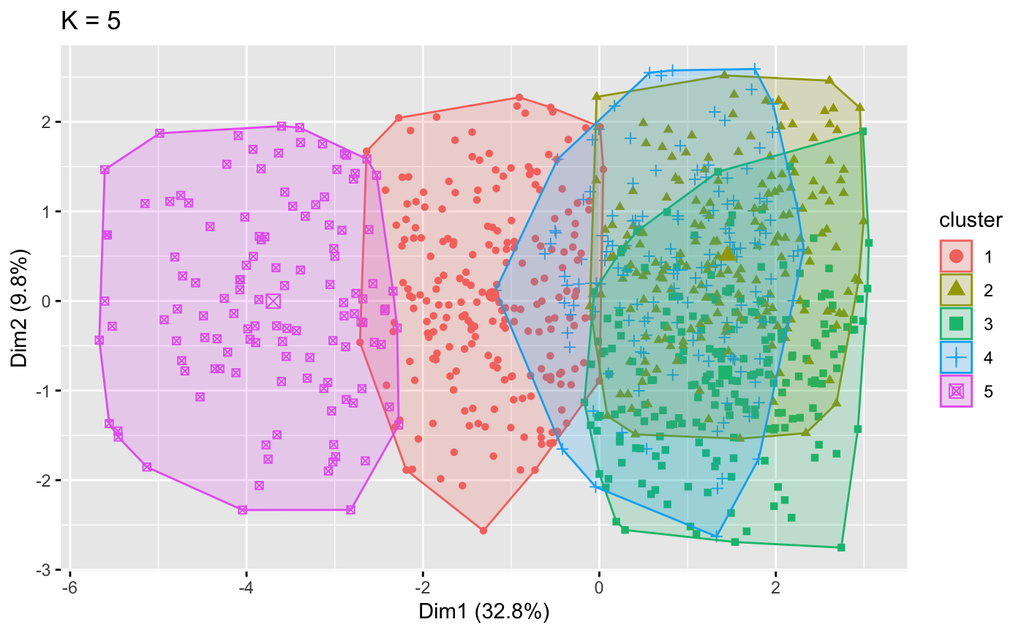

```r
fviz_cluster(kmeans_result, data = standardized_data, geom = "point",
             ellipse.type = "convex", main = paste("K =", k))
```

|  | k=3 | k=4 | k=5 |
| --- | --- | --- | --- |
| Average Silhouette width | 0.135 | 0.104 | 0.099 |
| Total Within-Cluster Sum of Square | 7452.95 | 7053.49 | 6736.48 |
| BCubed Precision | 1.0077 , 0.9698, 1.0176 | 0.987232 ,1.004458, 1.008847 ,1.003207 | 0.976906, 1.012718 ,1.022773, 0.9990613 ,0.9851579 |
| BCubed Recall | 1.040054, 0.9292188 ,1.03084 | 1.061042 , 1.024579 ,0.8550705 , 1.017749 | 1.051019 ,1.019177, 1.025443 ,1.037671 ,0.8456054 |

####In pursuit of predicting supermarket ratings, I have decided to leverage a classification approach as my primary methodology. The provided metrics, including accuracy, precision, sensitivity, and specificity, align with the goals of accurately predicting class labels for supermarket ratings. The emphasis on achieving a balance between true positives, true negatives, and minimizing false positives indicates the suitability of a classification framework. This choice is driven by the explicit objective of predicting supermarket ratings, making use of labeled data and optimizing the model’s performance based on key classification metrics.

###References:

[1]“GeeksforGeeks | A computer science portal for geeks,” GeeksforGeeks. https://www.geeksforgeeks.org/

[2]“Stack Overflow - Where Developers Learn, Share, & Build Careers,” Stack Overflow. https://stackoverflow.com/

[3]“List of Useful R Packages | Best Libraries of R Programming Language,” Statistics Globe, Oct. 14, 2021. https://statisticsglobe.com/r-packages-list/

[4]“RPubs - Data Mining: Classification with Decision Trees,” RPubs - Data Mining: Classification with Decision Trees, Jul. 12, 2016. https://rpubs.com/kjmazidi/195428

[5]“Supermarket sales,” Supermarket sales | Kaggle. https://www.kaggle.com/datasets/aungpyaeap/supermarket-sales